# Analysis of Dataset D

**CRITERIA FOR THE RESPONSES**

```r
dataset <- dataset %>%
  mutate(criteria...183 = tolower(criteria...183))
unique(dataset$criteria...183)
```

```
##  [1] "clinical criteria"             "recist 1.1"
##  [3] "na"                            NA
##  [5] "investigator's criteria"       "irecist"
##  [7] "investigator"                  "clinical criteria, recist 1.1"
##  [9] "recist 1.1, clinical criteria" "investigator criteria"
## [11] "recist"                        "recist 1,1"
## [13] "clinical pd"
```

```r
dataset <- dataset %>%
  mutate(criteria...183 = case_when(
    criteria...183 %in% c("investigator", "investigator's criteria","investigator criteria" ) ~ "investigator",
    criteria...183 %in% c("recist 1.1", "recist 1,1", "recist") ~ "RECIST 1.1",
    criteria...183 %in% c("clinical criteria", "clinical pd") ~ "clinical",
    criteria...183 %in% c("clinical criteria, recist 1.1", "recist 1.1, clinical criteria") ~ "mixed",
    criteria...183 == "na" ~ NA_character_,
    criteria...183 == "irecist" ~ "iRECIST",
    TRUE ~ criteria...183
  ))
```

```r
table(dataset$criteria...183)
```

```
##
##     clinical investigator      iRECIST        mixed   RECIST 1.1
##           59          302            5            3          719
```

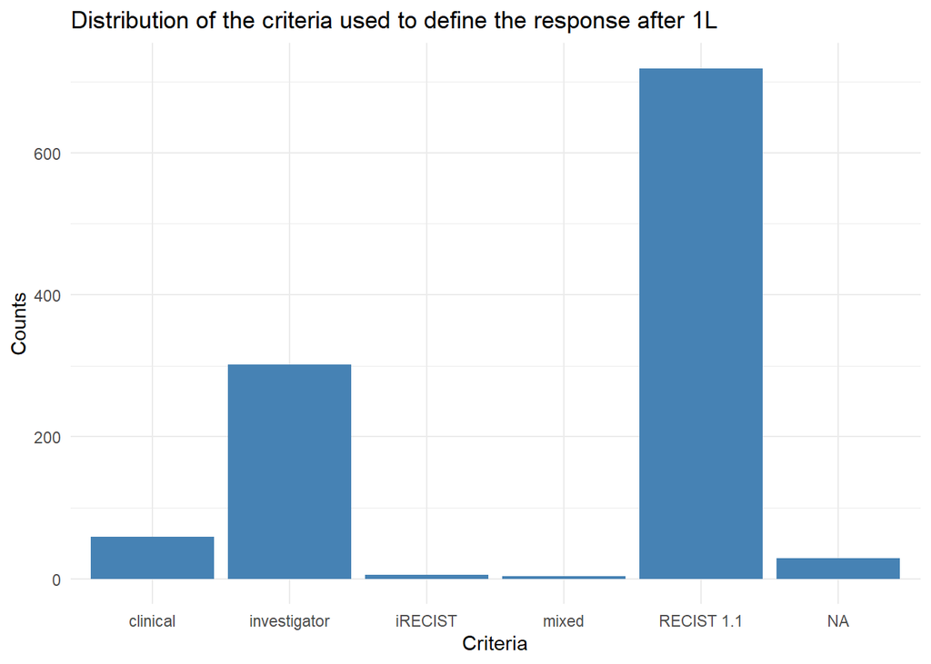

```r
ggplot(dataset, aes(x = criteria...183)) +
  geom_bar(fill = "steelblue") +
  labs(title = "Distribution of the criteria used to define the response after 1L",
       x = "Criteria",
       y = "Counts") +
  theme_minimal()
```

**PD AFTER L1**

```r
class(dataset$`pd_1l_yes=1`)
```

```
## [1] "numeric"
```

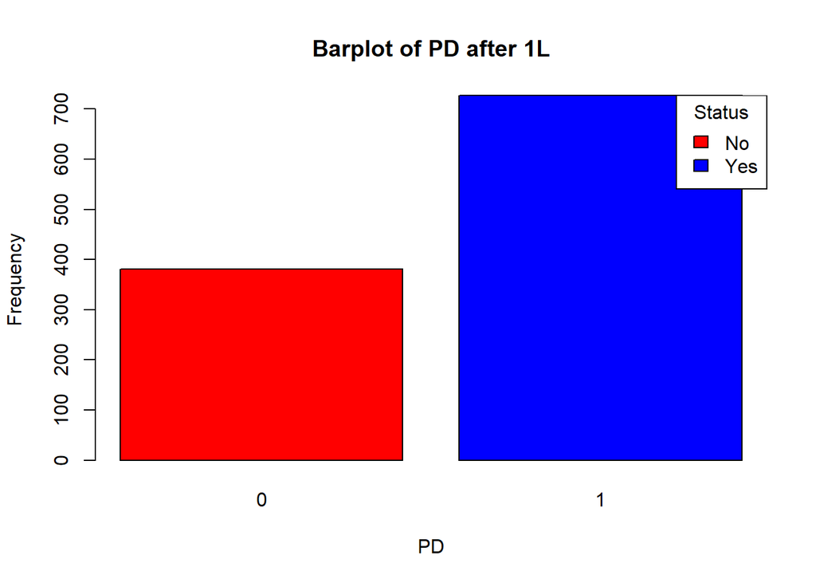

```r
counts <- table(dataset$`pd_1l_yes=1`, useNA = "no")

colors <- c("red", "blue")
category_labels <- c("No", "Yes")

barplot(counts,
            col = colors,
            main = "Barplot of PD after 1L",
            xlab = "PD",
            ylab = "Frequency",
            names.arg = names(counts),
            border = "black")


legend("topright",
           legend = category_labels,
           fill = colors,
           title = "Status",
           border = "black")
```

```r
sum(is.na(dataset$`pd_1l_yes=1`))
```

```
## [1] 9
```

```r
length(dataset$`pd_1l_yes=1`)
```

```
## [1] 1117
```

0,8%, perfect!

**PROGRESSION**

```r
class(dataset$progression)
```

```
## [1] "numeric"
```

There are case with a negative progression: the progression is registered before the start of the 1L: how can I manage these cases (even if they are only 5)?

```r
dataset %>%
  filter(!is.na(progression), progression < 0) %>%
  select(date_start_1l, date_pd__1l,`date_of_last_visit/death`, `pd_1l_yes=1`, `event_os=_death_yes`, progression)
```

```
## # A tibble: 5 × 6
##   date_start_1l date_pd__1l `date_of_last_visit/death` `pd_1l_yes=1`
##   <date>        <date>      <date>                             <dbl>
## 1 2021-07-07    2021-01-14  2021-03-01                             1
## 2 2019-06-17    2019-04-25  2020-11-01                             1
## 3 2019-11-15    2019-08-22  2019-10-18                             1
## 4 2018-11-09    2018-09-12  2020-11-16                             1
## 5 2022-08-19    2022-06-13  2025-02-17                             1
## # ℹ 2 more variables: `event_os=_death_yes` <dbl>, progression <dbl>
```

To see the distribution, so fo analysis purposes, we discard them

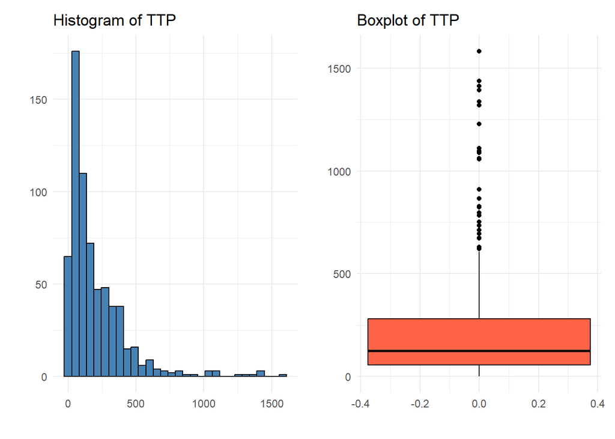

```r
# Histogram (progression > 0)
hist_plot <- ggplot(dataset %>% filter(progression >= 0), aes(x = progression)) +
  geom_histogram(fill = "steelblue", color = "black", bins = 30) +
  labs(title = "Histogram of TTP", x = "", y = "") +
  theme_minimal()

# Boxplot (progression > 0)
box_plot <- ggplot(dataset %>% filter(progression >= 0), aes(x = progression)) +
  geom_boxplot(fill = "tomato", color = "black", outlier.shape = 19) +
  coord_flip() +
  labs(title = "Boxplot of TTP", x = "", y = "") +
  theme_minimal()

hist_plot + box_plot
```

```r
sum(is.na(dataset$progression))
```

```
## [1] 445
```

```r
length(dataset$progression)
```

```
## [1] 1117
```

but in the case we would consider the negative values (5) as missing ones the total NA values would become 450 so 40,3% (different samples would be dropped, then)

#Response: method “K-means”

```r
data_filtered <- dataset %>% filter(progression >= 0)

# K-means (for 3 categories)
set.seed(123)
x_mat <- matrix(data_filtered$progression, ncol = 1)
k <- 3
kmeans_result <- kmeans(x_mat, centers = k)

centroids <- kmeans_result$centers[, 1]
cluster_order <- order(centroids)
data_filtered$progression_cat <- match(kmeans_result$cluster, cluster_order)

#
data_filtered$progression_cat <- factor(data_filtered$progression_cat,
                                     levels = 1:k,
                                     labels = c("bad_responder", "medium_no_responder", "good_responder"))
```

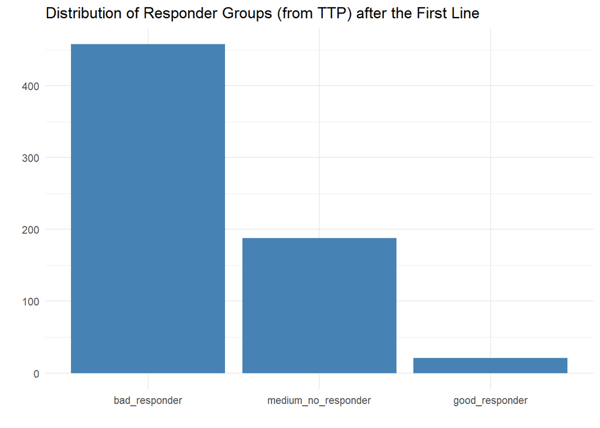

```r
ggplot(data_filtered, aes(x = progression_cat)) +
  geom_bar(fill = "steelblue") +
  labs(title = "Distribution of Responder Groups (from TTP) after the First Line",
       x = "",
       y = "") +
  theme_minimal()
```

```r
table(data_filtered$progression_cat)
```

```
##
##       bad_responder medium_no_responder      good_responder
##                 458                 188                  21
```

```r
data_filtered %>%
  group_by(progression_cat) %>%
  summarise(
    min = min(progression),
    min_months = round(min(progression) / 30.44, 2),
    max = max(progression),
    max_months = round(max(progression) / 30.44, 2)
  ) %>%
  print()
```

```
## # A tibble: 3 × 5
##   progression_cat       min min_months   max max_months
##   <fct>               <dbl>      <dbl> <dbl>      <dbl>
## 1 bad_responder           0       0      228       7.49
## 2 medium_no_responder   231       7.59   712      23.4
## 3 good_responder        735      24.2   1582      52.0
```

**Progression_log**

```r
data_filtered$progression_log <- log1p(data_filtered$progression)
```

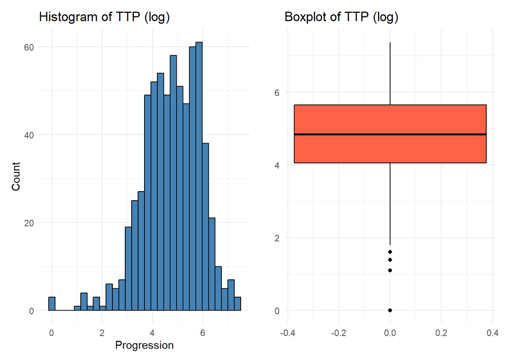

```r
# Histogram
hist_plot <- ggplot(data_filtered, aes(x = progression_log)) +
  geom_histogram(fill = "steelblue", color = "black", bins = 30) +
  labs(title = "Histogram of TTP (log)", x = "Progression", y = "Count") +
  theme_minimal()

# Boxplot
box_plot <- ggplot(data_filtered, aes(x = progression_log)) +
  geom_boxplot(fill = "tomato", color = "black", outlier.shape = 19) +
  coord_flip() +
  labs(title = "Boxplot of TTP (log)", x = "", y = "") +
  theme_minimal()


hist_plot + box_plot
```

```r
library(tidyr)
library(e1071)
skewness(data_filtered$progression, na.rm = TRUE)
```

```
## [1] 2.66846
```

```r
skewness(data_filtered$progression_log, na.rm = TRUE)
```

```
## [1] -0.6042347
```

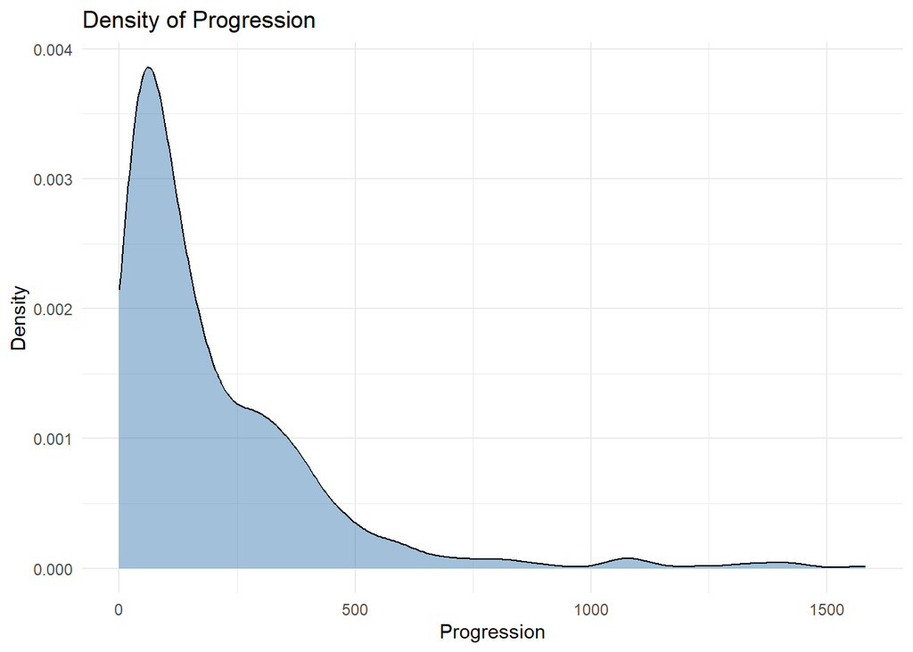

```r
ggplot(data_filtered, aes(x = progression)) +
  geom_density(fill = "steelblue", alpha = 0.5) +
  labs(title = "Density of Progression", x = "Progression", y = "Density") +
  theme_minimal()
```

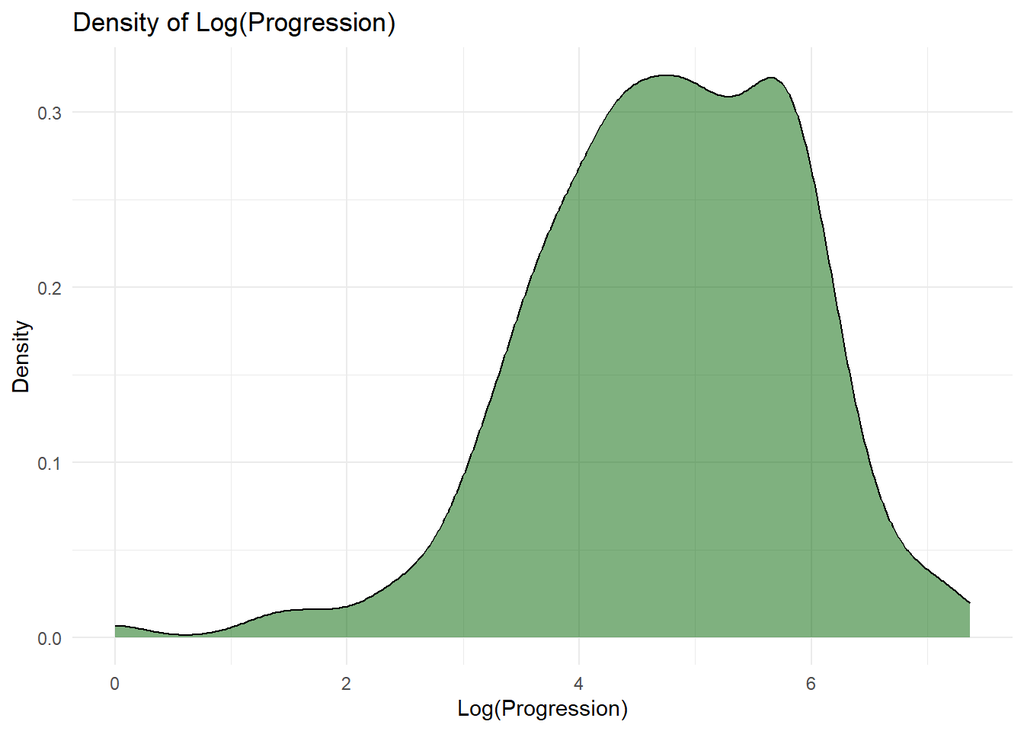

```r
ggplot(data_filtered, aes(x = progression_log)) +
  geom_density(fill = "darkgreen", alpha = 0.5) +
  labs(title = "Density of Log(Progression)", x = "Log(Progression)", y = "Density") +
  theme_minimal()
```

#Response2: method “K-means”

```r
# K-means (for 3 categories)
set.seed(123)
x_mat <- matrix(data_filtered$progression_log, ncol = 1)
k <- 3
kmeans_result <- kmeans(x_mat, centers = k)

centroids <- kmeans_result$centers[, 1]
cluster_order <- order(centroids)
data_filtered$progression_log_cat <- match(kmeans_result$cluster, cluster_order)

#
data_filtered$progression_log_cat <- factor(data_filtered$progression_log_cat,
                                     levels = 1:k,
                                     labels = c("bad_responder_log", "medium_no_responder_log", "good_responder_log"))
```

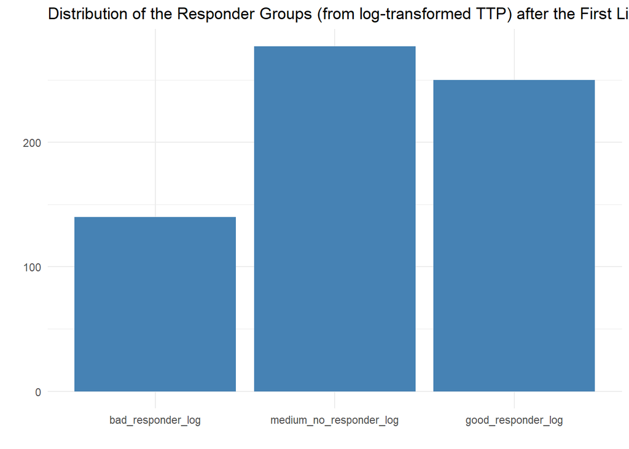

```r
ggplot(data_filtered, aes(x = progression_log_cat)) +
  geom_bar(fill = "steelblue") +
  labs(title = "Distribution of the Responder Groups (from log-transformed TTP) after the First Line",
       x = "",
       y = "") +
  theme_minimal()
```

```r
table(data_filtered$progression_log_cat)
```

```
##
##       bad_responder_log medium_no_responder_log      good_responder_log
##                     140                     277                     250
```

```r
data_filtered %>%
  group_by(progression_log_cat) %>%
  summarise(
    min_days = min(progression),
    min_months = round(min_days / 30.44, 2),
    max_days = max(progression),
    max_months = round(max_days / 30.44, 2)
  ) %>%
  print()
```

```
## # A tibble: 3 × 5
##   progression_log_cat     min_days min_months max_days max_months
##   <fct>                      <dbl>      <dbl>    <dbl>      <dbl>
## 1 bad_responder_log              0       0          46       1.51
## 2 medium_no_responder_log       47       1.54      183       6.01
## 3 good_responder_log           186       6.11     1582      52.0
```